# R Notebook1

Head First Statistics < Chapter 1 >

## 통계란?

통계는 ’날 것 그대로의 사실과 숫자’를 ’뭔가 의미 있는 방식으로 정리’해 주는 수입니다. 데이터 안에 일정한 법칙이나 경향이 존재하는 경우 그래프는 데이터 안에 존재하는 그 규칙들을 볼 수 있게 합니다.

원시 데이터 그 자체는 숫자의 나열일 뿐이며 겉으로 보는 것만으로는 파악하기 어려운 경우가 많습니다. 통계의 다양한 시각화(visualize) 방법을 를 통해 데이터의 핵심적인 내용을 꿰뚫어 볼 수 있습니다.

우리는 통계로 원시 데이터에 의미를 부여할 수도 있습니다. 이 말은 통계적으로 재구성된 데이터에는 해석을 유도하는 의도가 숨어있을 수 있음을 말해줍니다. 동일한 데이터일지라도 자료해석과 시각화 방법에 따라 다른 해석이 가능하기 때문이지요.

이해를 돕기 위해 동일한 데이터로 만든 다음의 두 그래프를 살펴봅시다.

p.45

```r
d <- data.frame(month=c(7,8,9,10,11,12),
                profit=c(2.0, 2.1, 2.2, 2.1, 2.3, 2.4))
head(d)
```

|  | month | profit |
| --- | --- | --- |
| 1 | 7 | 2.0 |
| 2 | 8 | 2.1 |
| 3 | 9 | 2.2 |
| 4 | 10 | 2.1 |
| 5 | 11 | 2.3 |
| 6 | 12 | 2.4 |

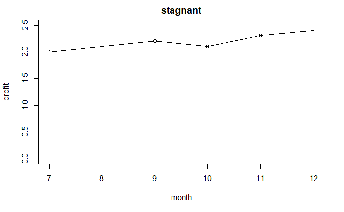

```r
plot(d, type="o", ylim=c(0.0, 2.5), main="stagnant")
```

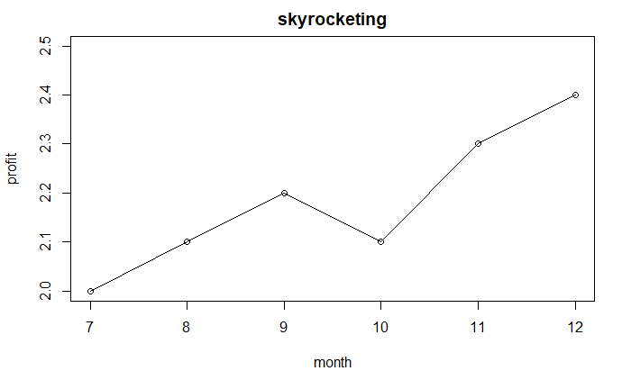

```r
plot(d, type="o", ylim=c(2.0, 2.5), main="skyrocketing")
```

*plot(데이터명, type=“그래프유형”, lty=“선유형”) 그래프유형 : 꺾은선(l) , 접과선(b), 접과선 중첩(o) 등 선유형 : blank, solid, dashed, dotted, totdash, longdash, twodash 등* xlim=c(숫자, 숫자) : 그래프 x축 범위 지정 ylim=c(숫자, 숫자) : 그래프 y축 범위 지정

y축 범위를 지정함으로써 이처럼 상반된 인상을 심어줄 수 있습니다.

여기에 통계학을 배워야 하는 이유가 있습니다. 우리는 숫자에 속지 않기 위해서 주어진 자료를 비판적이고 능동적으로 해석하는 연습을 해야 합니다.

정보와 데이터는 조금 차이가 있습니다. 데이터는 수집된 날 것 그대로의 사실과 숫자를 의미하고, 정보는 약간의 의미가 부여된 데이터를 가리킵니다. 예컨대, ’4, 5, 6’이라는 숫자는 데이터입니다. 그런데 이 데이터가 학년을 의미한다는 부연설명이 있다면 정보가 됩니다.

## 그래프 종류

실제로 드러내고자 하는 메시지가 무엇인지, 최소한으로 나타낼 사실이 무엇인지에 따라 사용할 그래프가 결정됩니다. 이번 글에서는 크게 네 종류(파이, 막대, 히스토그램, 누적도수)의 그래프를 살펴보겠습니다. 각 그래프의 특징이 무엇인지 살펴보고 언제 유용하게 쓰일지 확인해봅시다.

먼저 ’파이 그래프’입니다. 파이차트는 파이(Pie)를 조각내어 나누듯이, 전체 100%를 각 도수의 상대적인 크기(비율)로 나누어 보여줍니다. 도수는 어떤 특정한 그룹이나 범위 안에 얼마나 많은 항목이 들어 있는지 나타내는 값입니다. 도수의 상대적인 비율을 비교할 때 유용하지만 그 비율이 비슷한 경우에는 차이가 잘 구분되지 않습니다.

p.48

```r
d1 <- data.frame(genre=c("sports", "strategy", "action", "shooting", "etc"),
       volume=c(27500, 11500, 6000, 3500, 1500))
head(d1)
```

|  | genre | volume |
| --- | --- | --- |
| 1 | sports | 27500 |
| 2 | strategy | 11500 |
| 3 | action | 6000 |
| 4 | shooting | 3500 |
| 5 | etc | 1500 |

```r
pct <- round(d1$volume / sum(d1$volume) * 100)
head(pct)
```

```
[1] 55 23 12  7  3
```

```r
d2 <- data.frame(genre=c("sports", "strategy", "action", "shooting", "etc"),
                volume=c(27500, 11500, 6000, 3500, 1500),
                pct)
head(d2)
```

|  | genre | volume | pct |
| --- | --- | --- | --- |
| 1 | sports | 27500 | 55 |
| 2 | strategy | 11500 | 23 |
| 3 | action | 6000 | 12 |
| 4 | shooting | 3500 | 7 |
| 5 | etc | 1500 | 3 |

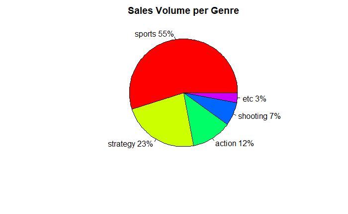

```r
lbls <- paste(d2$genre," ", pct, "%", sep="")
pie(d2$volume, lbls, col=rainbow(length(lbls)), main="Sales Volume per Genre")
```

더욱 정밀한 수치를 비교하고자 할 때는 ’막대 그래프’를 사용합니다. 막대 그래프는 x축과 y축의 구분에 따라 수직/수평 막대그래프로 구분되고, 둘 이상의 데이터를 표현할 때 그 방법에 따라 분할/조각 막대그래프로 사용할 수 있습니다. 일반적으로 사용하는 수직 막대그래프는 x축에 범주를, y축에 도수를 나타냅니다.

p.50

```r
d <- data.frame(field=c("A", "B", "C", "D", "E"),
                volume=c(1000, 5000, 7500, 8000, 9500))
head(d)
```

|  | field | volume |
| --- | --- | --- |
| 1 | A | 1000 |
| 2 | B | 5000 |
| 3 | C | 7500 |
| 4 | D | 8000 |
| 5 | E | 9500 |

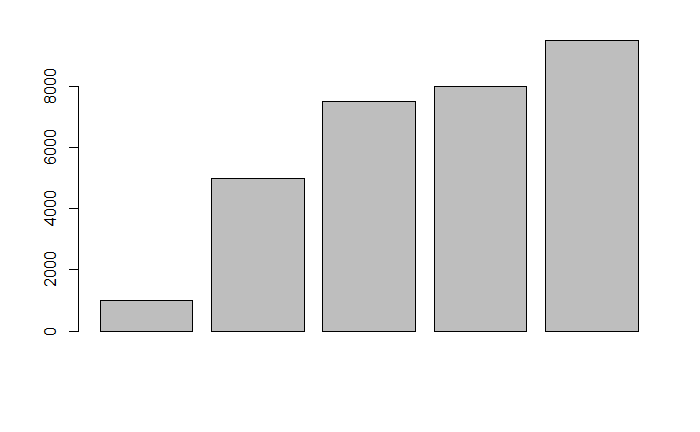

```r
barplot(d$volume)
```

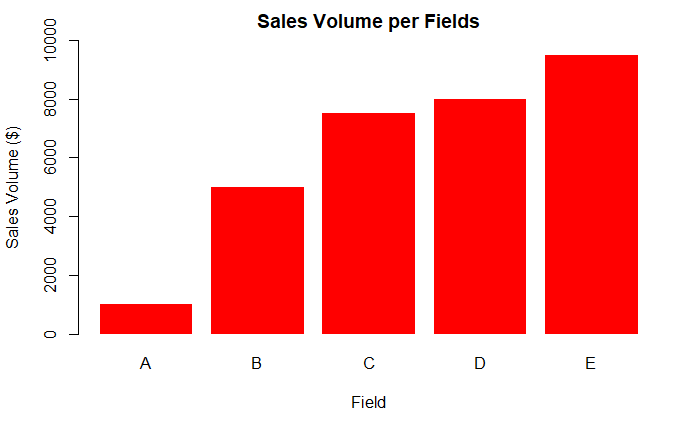

```r
barplot(d$volume, names.arg=d$field,
        col= "red",
        border = NA,
        xlab = "Field",
        ylab = "Sales Volume ($)",
        ylim = c(0, 10000),
        main = "Sales Volume per Fields")
```

범주의 이름이 길 때는 수평 막대그래프를 사용합니다. 둘 이상의 데이터 집합을 표현할 때, 도수를 서로 비교하고자 한다면 분할된 범주의 막대그래프를, 도수와 퍼센트를 동시에 나타내고자 한다면 조각으로 나누어진 막대그래프를 사용합니다.

p.61-62

```r
a <- sample(0:199, 5)
b <- sample(200:399, 29)
c <- sample(400:599, 56)
d <- sample(600:799, 17)
e <- sample(800:999, 3)
crazymango <- c(a, b, c, d, e)
head(crazymango)
```

```
[1]  34  20  55  83  88 223
```

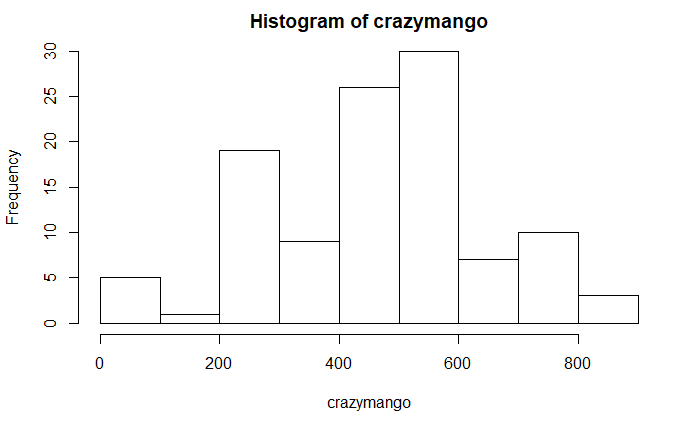

```r
hist_crazymango <- hist(crazymango)
```

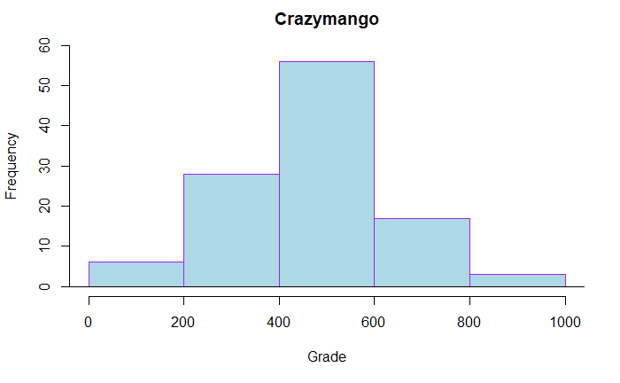

```r
hist_crazymango <- hist(crazymango,
                        breaks=5, ylim=c(0,60),
                        xlab="Grade", main="Crazymango",
                        col="light blue", border="purple")
lines(density(crazymango))
```

막대의 면적이 도수에 비례하기 때문에 도수의 밀도 개념이 존재합니다. 도수밀도는 특정 구간에 속한 값들의 집중도를 나타내며, 도수를 그룹의 폭으로 나눈 값입니다. 막대의 높이에 따라 높으면 고밀도, 낮으면 저밀도를 의미합니다. * 범주적 데이터는 단어(word)와 정성(quality)을 다루며, 수치적 데이터는 숫자(number)와 정량(quantity)을 다룹니다.

p.71-72

```r
AngryBull <- data.frame(grade=c(0,1,2,3,4,5),
                        width=c(1,1,1,1,1,1),
                        density=c(10,30,50,30,10,10))
AngryBull <- data.frame(AngryBull,
                        frequency=c(AngryBull$width * AngryBull$density))
head(AngryBull)
```

|  | grade | width | density | frequency |
| --- | --- | --- | --- | --- |
| 1 | 0 | 1 | 10 | 10 |
| 2 | 1 | 1 | 30 | 30 |
| 3 | 2 | 1 | 50 | 50 |
| 4 | 3 | 1 | 30 | 30 |
| 5 | 4 | 1 | 10 | 10 |
| 6 | 5 | 1 | 10 | 10 |

```r
hist(xlab=AngryBull$grade, ylab=AngryBull$density)
```

[output not shown]

cf) p.61-62 자료를 이용한 도수밀도

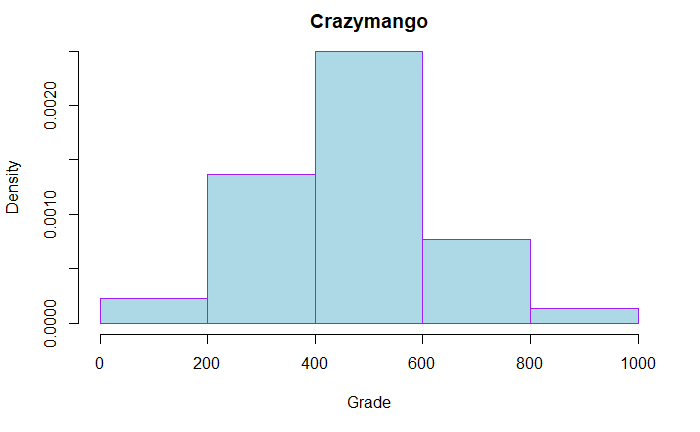

```r
hist_crazymango <- hist(crazymango,
                        breaks=5,
                        xlab="Grade", main="Crazymango",
                        col="light blue", border="purple", freq = FALSE)
```

### 오류 발생,,

p.78

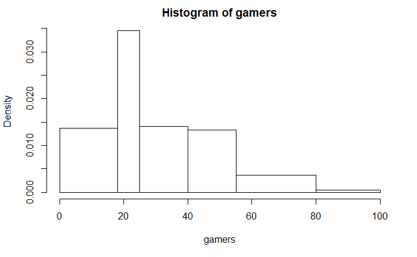

```r
a1 <- sample(0:17, size=2000, replace=TRUE)
a2 <- sample(18:24, size=2500, replace=TRUE)
a3 <- sample(25:39, size=2000, replace=TRUE)
a4 <- sample(40:54, size=2000, replace=TRUE)
a5 <- sample(55:79, size=900, replace=TRUE)
a6 <- sample(80:99, size=100, replace=TRUE)
gamers <- c(a1, a2, a3, a4, a5, a6)
hist_gamers <- hist(gamers,
                    breaks=c(0,18,25,40,55,80,100))
```

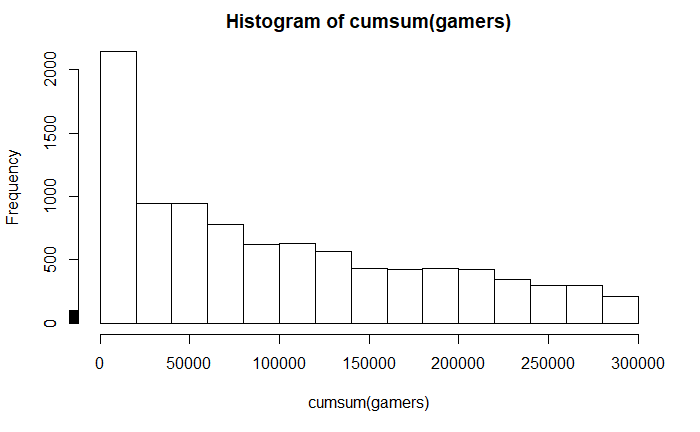

```r
hist_test <- hist(cumsum(gamers))
test <- axis(gamers, side = 2)
```

```r
hist_gamers2 <- hist(cumsum(length(gamers)),
                     breaks=c(0,18,25,40,55,80,100))
```

[output not shown]

[output not shown]

[output not shown]